# Data Quality Report

2022 Mpox Multi-Jurisdictional Case-Control VE Public Health Evaluation

Report by Case-Control Unit | VE Team | VTF | 2022 Multinational Monkeypox Response

07 February 2023

## **Report objective**

Examine data quality, clean data, and create analysis variables.

```r
# Data in: Pulled data directly from REDCap using API token
# Initial program date: 2022-12-15
# Last modified date: 2023-01-20

# Load packages --------------------------------
  pacman::p_load(here,        # file paths relative to R project root folder
                 rio,         # import/export
                 readxl,      # read excel files
                 tidyverse,    # data management and visualization
                 purrr,        # iteration
                 janitor,      # data management: cleaning and exploring data
                 lubridate,    # working with dates/epiweeks
                 naniar,       # Working with data structures, summaries, and visualizations for Missing Data
                 arsenal,      # provides unctions for large-scale statistical summaries
                 ggsci,        # scientific journal and sci-fi themed color palettes for 'ggplot2'
                 cowplot,      # streamlined plot theme and plot annotations for 'ggplot2'
                 knitr,        # Provides a general-purpose tool for dynamic report generation in R
                 kableExtra,   # simplifies the way to manipulate the HTML or 'LaTeX' codes generated by 'kable()
                 DT,           # provides an R interface to the JavaScript library DataTables
                 gtsummary,    # publication-ready analytical and summary tables
                 stargazer,    # provides a way to create publication quality tables
                 plotly        # creates interactive web-based graphs


  )

# Global option number format
  options(scipen = 9999)

#GT Table Theme
  theme_gtsummary_journal(journal = "jama")
  theme_gtsummary_compact()
# Helper (custom functions) ------------------------------------------------------------
#This function replicates the SAS proc freq function with the '/ list missing statement'.
#Source: https://github.com/asnr/sas-to-r
pfreq = function(...) {
  dplyr::group_by(...) %>%
    dplyr::summarize(n = n()) %>%
    dplyr::mutate(pct= round(100 * n/sum(n), 1))
  #mutate(Percent=paste0(round(100 * n/sum(n), 1), "%"))
}

# This function helps create consistent values for Yes/No variables.
# by reassigning '2' values a zero.
give_two_a_zero <- function(x){
  x[x == 2 ] <- 0
  x
}


# Source data and define environment variables ---------------------------------------------------------------------

  source("00_REDCap-API-linkage.R", local =knit_global())

  # raw <- here("data", "MultiJurisdictionalM_DATA_2023-01-21_2201.csv") %>%
  # read_csv()

  # Environment variables for Rmarkdown purpose
    # This the date of the earliest symptom per the study protocol

      eligibility_date_v2 <- "19 Aug 2022"

    # This date represent the most recent data transfer from jurisdictions

      redcap_trans_date_v2 <- "03 Feb 2023"

# Tidy data ----------------------------------------------------------------------
mpoxve <- raw %>%
    # Restrict to eligible respondents (i.e., those that passed the eligibility screening)
    filter(inelig_stop ==  1) %>%
    # Restrict to those who have data for relevant eligibility screening questions
    filter(!if_all(c(elig_age, elig_sexuality, elig_gender,
                     elig_gender_msm, elig_sexual_partners,
                     elig_healthcare), is.na)) %>%
    mutate(#! Variable name key:
               #!  *_cat: indicates a categorical these are flags (0/1)
               #!  *_f: these are flags (0/1)
               #!  *_na: these are also flags but specifically related to missingness (NA = missing in R)
               #!  *_int: these refer to some calculate interval
               #!  pd: an abbreviation for period


    #==== General variable cleaning ----

          # Format all yes/no variables with 1(Yes)/2(No) values as 1(Yes)/0(No).
           across(contains(c("elig_age", "elig_gender_msm", "elig_sexual_partners",
                             "elig_healthcare", "first_dose_yesno", "second_dose_yesno",
                             "symptoms_yesno", "provider_dx", "clinic_yesno", "hospitalized",
                             "dose1_yesno", "dose2_yesno"), ignore.case = TRUE), give_two_a_zero),

           # Format all date variables as YYYY-MM-DD
           across(contains("_date", ignore.case = TRUE), ymd),
           # Check the presence of a jurisdiction ID
           juris_detect = case_when(str_detect(pid, "CA_|CO_| CT_|DC_|GA_|LAC_|MD_|MN_|NYC_|NYS_|OR_|TN_") ~ 1,
                           TRUE ~ as.numeric(0)),

           # Rename REDCap Data Access Group variable and capitalize the letters
           jid = fct_relevel(as_factor(toupper(redcap_data_access_group)),
                             "CA", "LAC", "CO", "CT", "GA", "MD", "MN",
                             "NYS", "NYC", "OR", "TN", "DC"),

    #==== Index date (mpox symptom onset [for cases] or clinic visit date [for controls]) ----

         # Create a study period variable to store mpox symptoms date within 2022-08-19 and most recent data transfer
          eligibility_date = ymd("2022-08-19"),
          redcap_trans_date = ymd("2023-02-03"),

          study_pd_int = interval(eligibility_date, redcap_trans_date),

          index_date = case_when(test_result_date %within% study_pd_int ~ test_result_date,
                                  ((is.na(test_result_date) | #if incomplete or
                                     (test_result_date < eligibility_date)) & # before Aug 19
                                       (symptoms_date %within% study_pd_int)) ~ symptoms_date,
                                  clinic_date %within% study_pd_int ~ clinic_date,
                                  ((is.na(clinic_date) | #if incomplete or
                                      (clinic_date < eligibility_date)) & # before Aug 19
                                       (control_visit_date %within% study_pd_int)) ~ control_visit_date,
                                  TRUE ~ as.Date(NA)),


    #==== Case ascertainment----
          #  2022-01-18 data call decisions:
          #      Cases: Use site test result date, and if missing, use self-reported symptoms date
          #      Controls: Use self-report clinic date, if self-reported missing OR before Aug 19th,
          #                then use the sit- reported clinic date
```

```r
          # Case status categories
           caco_stat_cat = fct_relevel(as_factor(case_when(

                                                  case_yesno %in% c(1,2) & # Site-reported as confirmed or probable case
                                                    provider_dx == 1 &
                                                    is.na(index_date)      ~ "Case: invalid date",

                                                  case_yesno %in% c(1,2) & # Site-reported as confirmed or probable case
                                                    (provider_dx == 0 &
                                                       clinic_yesno == 1) ~ "Case-site, Control-self",

                                                  case_yesno %in% c(1,2) & # Site-reported as confirmed or probable case
                                                    (provider_dx == 0 &
                                                       clinic_yesno != 1) ~ "Case: self-no dx & clinic visit",

                                                  case_yesno %in% c(1,2) & # Site-reported as confirmed or probable case
                                                    provider_dx == 1 &
                                                    !is.na(index_date)     ~ "Case",

                                                  case_yesno == 3 & # Site-reported as control
                                                    provider_dx == 1     ~ "Control-site, Case-self",

                                                 case_yesno == 3 & # Site-reported as confirmed or probable case
                                                    provider_dx != 1 &
                                                    is.na(index_date) ~ "Control: invalid date",

                                                  case_yesno == 3 & # Site-reported as control
                                                    clinic_yesno != 1 &
                                                    !is.na(index_date)  ~ "Control: no clinic visit-self",

                                                  case_yesno == 3 & # Site-reported as control
                                                   clinic_yesno == 1 &
                                                    #provider_dx != 1 &
                                                    !is.na(index_date)    ~ "Control",


                                                  is.na(case_yesno) ~ "Site-report missing",

                                                  TRUE ~ as.character(NA))),
                              "Case",
                              "Case: invalid date",
                              "Case: self-no dx & clinic visit",
                              "Control",
                              "Control: no clinic visit-self",
                              "Control: invalid date",
                              "Case-site, Control-self",
                              "Control-site, Case-self",
                              "Site-report missing"),

    # binary case status: main analysis
    caco = fct_relevel(as_factor(case_when(caco_stat_cat %in% c("Case",
                                                                "Control-site, Case-self",
                                                                "Case: self-no dx & clinic visit") ~ "Case",
                                           caco_stat_cat %in% c("Control",
                                                                "Case-site, Control-self",
                                                                "Control: no clinic visit-self") ~ "Control",
                                           TRUE ~ as.character(NA))),
                       "Case", "Control"),

    # binary case status: sensitivity analysis, controls who did not self-report as having clinic visit
    caco_sen = fct_relevel(as_factor(case_when(caco_stat_cat %in% c("Case") ~ "Case",
                                               caco_stat_cat %in% c("Control") ~ "Control",
                                               TRUE ~ as.character(NA))),
                           "Case", "Control"),

  # Re assign index dates
  index_date = case_when((caco_stat_cat == "Control-site, Case-self" &
                                       (symptoms_date %within% study_pd_int)) ~ symptoms_date,
                                     (caco_stat_cat == "Case-site, Control-self" &
                                       (clinic_date %within% study_pd_int)) ~ clinic_date,
                                     !caco_stat_cat %in%c("Control-site, Case-self", "Case-site, Control-self") ~ index_date,
                                     TRUE ~ as.Date(NA)),

  index_yrmo = format_ISO8601(index_date, precision = "ym"),
  #==== Vaccination Status ----
          # Combine site- and self-reported vaccination dose variables
          vax1_yesno = case_when((is.na(dose1_yesno) & !is.na(first_dose_yesno)) |
                                   (dose1_yesno == 0 & first_dose_yesno == 1)      ~ first_dose_yesno,
                           TRUE ~ as.numeric(dose1_yesno)),

          vax1_date = case_when(is.na(dose1_date) &
                                  first_dose_yesno == 1 & !is.na(first_dose_date) ~ first_dose_date,
                           TRUE ~ as.Date(dose1_date)),

          vax1_yrmo = format_ISO8601(vax1_date, precision = "ym"),

          vax2_yesno = case_when((is.na(dose2_yesno) & !is.na(second_dose_yesno)) |
                                   (dose2_yesno == 0 & second_dose_yesno == 1) ~ second_dose_yesno,
                           TRUE ~ as.numeric(dose2_yesno)),

          vax2_date = case_when(is.na(dose2_date) &
                                  second_dose_yesno == 1 & !is.na(second_dose_date) ~ second_dose_date,
                           TRUE ~ as.Date(dose2_date)),

          vax2_yrmo = format_ISO8601(vax2_date, precision = "ym"),

          # Time (days) between index event date and 1st/2nd doses
          dose1index_days = index_date - vax1_date,

          dose2index_days = index_date - vax2_date,
```

```r
          dose_int        = vax2_date - vax1_date,

          # Vax status: Site
          vax_stat_na = as.character(NA),
          vax_stat = fct_relevel(as_factor(case_when(!is.na(index_date) &
                                                       ((vax1_yesno == 0 &  # no documented vaccination OR Post index event vax
                                                                 is.na(vax2_yesno))|
                                                          (vax1_date >= index_date)) ~ "Unvaccinated",
                                                     (vax1_yesno == 1 &                   # 1 dose but dose1-index date interval < 14 days
                                                           dose1index_days <= 13)    ~ "PEP",
                                                     ((vax1_yesno == 1 & vax2_yesno != 1 &   # 1 dose partial (1st dose but no 2nd dose)
                                                        dose1index_days >= 14) |
                                                       (vax1_yesno == 1 & vax2_yesno == 1 &  # D1 is <24 days before D2
                                                          dose1index_days >= 14 &
                                                          dose_int <24) |
                                                       (vax2_yesno == 1 &                  # 2 doses partial
                                                          dose1index_days >= 14 &          # (dose 2-index date interval < 14 days )
                                                          dose_int >=24 & dose2index_days < 14)) ~ "Partially vaccinated",
                                                     (vax2_yesno == 1 &
                                                        dose_int >=24 & dose2index_days >= 14) ~ "Fully vaccinated",
                                                     TRUE ~ as.character(vax_stat_na))),
                                 "Fully vaccinated", "Partially vaccinated", "PEP", "Unvaccinated"),

         # Exclude those who had 2 doses but D1 is <24 days before D2 for VE analysis
         vax_stat_ve = case_when((vax1_yesno == 1 & vax2_yesno == 1 &
                                 dose1index_days >= 14 & dose_int <24) ~ NA_character_,
                                 TRUE ~ as.character(vax_stat)),

    #==== Minimum set variables ----
    # Create indicator vars to help flag records missing minimum set of data elements need for VE  variables
          minset_vars = fct_relevel(as_factor(case_when(is.na(case_yesno) |
                                                          is.na(vax1_yesno) |
                                                          (vax1_yesno == 1 & is.na(vax1_date)) |
                                                          (vax1_yesno == 1 & is.na(vax2_yesno)) |
                                                          (vax2_yesno == 1 & is.na(vax2_date)) |
                                                          #is.na(provider_dx) |
                                                                 #is.na(clinic_yesno) |
                                                                 is.na(index_date) ~ "Incomplete",
                                                               TRUE ~ as.character("Complete"))),
                                          "Complete", "Incomplete"),

    #==== DQ Check: Non-vaccination ----

        # symptom Onset Date vs Test Date (Cases) - Compare symptom onset date to ensure same day as
        #                                           or before positive test result (cases only)

         symp_gt_test_date_f = fct_relevel(as_factor(case_when(caco == "Case" & !is.na(symptoms_date) &
                                                                 !is.na(test_result_date) &
                                                                 (symptoms_date >= test_result_date) ~ "Yes",
                                                               caco == "Case" & !is.na(symptoms_date) &
                                                                 !is.na(test_result_date) &
                                                                 (symptoms_date < test_result_date) ~ "No",
                                                               caco == "Control"                     ~ "Not applicable, control",
                                                             TRUE ~ as.character(NA))),
                                         "Yes", "No", "Not applicable, control"),

        # Clinic Visit Date – HD vs Self Report (Controls) - Compare  clinic visit as reported from HD compared to self-report
        #                                                    Flag if (clinic_date - control_visit_date) > +/- 2
         clinic_v_control_date = fct_relevel(as_factor(case_when(!is.na(clinic_date) & !is.na(control_visit_date) &
                                                                   (abs(clinic_date - control_visit_date) > 20) ~ "Abs > 20 days: Yes",
                                                                 !is.na(clinic_date) & !is.na(control_visit_date) &
                                                                   (abs(clinic_date - control_visit_date) <= 20) ~ "Abs > 20 days: No",
                                                                 TRUE ~ as.character(NA))),
                                             "Abs > 20 days: Yes", "Abs > 20 days: No"),
    #==== DQ Check: Vaccination variables ----

          # Dose 1 and Dose 2 Vaccination Interval (self-report) - Flag interval < 24 days and > 24 days to ID implausible intervals
          dose_int_self = ifelse(!is.na(first_dose_date) & !is.na(second_dose_date), second_dose_date - first_dose_date, NA),
          dose_int_cat_self = fct_relevel(as_factor(case_when(first_dose_yesno != 1                                   ~ "Not Vaxed",
                                                                !is.na(first_dose_date) & is.na(second_dose_date)    ~ "Dose #1 only",
                                                                !is.na(first_dose_date) & !is.na(second_dose_date) &
                                                                  ((second_dose_date - first_dose_date) < 24)        ~ "<24 days",
                                                             !is.na(first_dose_date) & !is.na(second_dose_date) &
                                                                  (((second_dose_date - first_dose_date) %in% c(24:28)))  ~ "24-28 days",
                                                                !is.na(first_dose_date) & !is.na(second_dose_date) &
                                                                  ((second_dose_date - first_dose_date) > 28)            ~ ">28 days",
                                                             TRUE ~ as.character(NA))),
                                       "Dose #1 only", "<24 days", "24-28 days", ">28 days", "Not Vaxed"),
```

```r
          # site-report: Dose 1 and Dose 2 Vaccination Interval - Flag interval < 24 days and > 24 days to ID implausible intervals
         dose_int_site = ifelse(!is.na(dose1_date) & !is.na(dose2_date), dose2_date - dose1_date, NA),
         dose_int_cat_site = fct_relevel(as_factor(case_when(dose1_yesno != 1                             ~ "Not Vaxed",
                                                              !is.na(dose1_date) & is.na(dose2_date)      ~ "Dose #1 only",
                                                              !is.na(dose1_date) & !is.na(dose2_date) &
                                                                ((dose2_date - dose1_date) < 24)          ~ "<24 days",
                                                           !is.na(dose1_date) & !is.na(dose2_date) &
                                                                  (((dose2_date - dose1_date) %in% c(24:28)))  ~ "24-28 days",
                                                              !is.na(dose1_date) & !is.na(dose2_date) &
                                                                ((dose2_date - dose1_date) > 28)          ~ ">28 days",
                                                           TRUE ~ as.character(NA))),
                                         "Dose #1 only", "<24 days", "24-28 days", ">28 days", "Not Vaxed"
                                                           ),
        # Vaccine Dose Number – HD vs Self Report: Compare number of vaccine doses reported from HD compared to self-report
          site_v_self_dose1 = fct_relevel(as_factor(case_when((dose1_yesno == 1 & first_dose_yesno == 1) |
                                                                (dose1_yesno == 0 & first_dose_yesno == 0) ~ "Same",
                                                              (dose1_yesno == 1 & first_dose_yesno == 0)   ~ "Site-Vax",
                                                              (dose1_yesno == 0 & first_dose_yesno == 1)   ~ "Self-Vaxed",
                                                              TRUE ~ as.character(NA))),
                                          "Same", "Site-Vax", "Self-Vaxed"),
          site_v_self_dose2 = fct_relevel(as_factor(case_when((dose2_yesno == 1 & second_dose_yesno == 1) |
                                                                (dose2_yesno == 0 & second_dose_yesno == 0) ~ "Same",
                                                              (dose2_yesno == 1 &
                                                                 (second_dose_yesno == 0 | is.na(second_dose_yesno)))   ~ "Site-Vax",
                                                              ((dose2_yesno == 0 | is.na(dose2_yesno)) &
                                                                 second_dose_yesno == 1)  ~ "Self-Vaxed",
                                                              TRUE ~ as.character(NA))),
                                          "Same", "Site-Vax", "Self-Vaxed"),

       # Vaccine Administration Date – HD vs Self Report: Compare dates of vaccination administration between
       #                                                  HD and self-report (add +/- 1 or 2 days)

        site_v_self_vaxdate1 = fct_relevel(as_factor(case_when(!is.na(dose1_date) & !is.na(first_dose_date) &
                                                                 (abs(dose1_date   - first_dose_date) > 2) ~ "Abs > 2: Yes",
                                                               !is.na(dose1_date) & !is.na(first_dose_date) &
                                                                 (abs(dose1_date   - first_dose_date) <= 2) ~ "Abs > 2: No",
                                                               TRUE ~ as.character(NA))),
                                         "Abs > 2: Yes", "Abs > 2: No"),

       site_v_self_vaxdate2 = fct_relevel(as_factor(case_when(!is.na(dose2_date) & !is.na(second_dose_date) &
                                                                (abs(dose2_date   - second_dose_date) > 2) ~ "Abs > 2: Yes",
                                                              !is.na(dose2_date) & !is.na(second_dose_date) &
                                                                (abs(dose2_date   - second_dose_date) <= 2) ~ "Abs > 2: No",
                                                              TRUE ~ as.character(NA))),
                                          "Abs > 2: Yes", "Abs > 2: No"),


      #==== DQ Check: Other vars ----
       # Check to make sure birth year is within range of a person being between 18-49 years old
       #               Invalid birth years/ages should be captured via REDCap checks, except for some unusual
       #                situations which should be reviewed and resolved on a case-by-case basis
              # Calculate age based on birth year and symptom or clinic date
              age_cal = year(index_date) - birth_year,
              # Flag if submitted date– birth_year <18 | > 49 (AOD: we do not have submitted date)
              age_f = fct_relevel(as_factor(case_when(age_cal < 18          ~ "<18",
                                                            age_cal %in% c(18:49) ~ "18-49",
                                                            age_cal > 49          ~ "\u226550",
                                                            TRUE ~ as.character(NA))),
                                        "<18", "18-49", "\u226550"),



         # Length of Hospitalization - Examine if length of days of hospitalization is longer than
          #                             the time between illness onset and survey submission
          #                             Flag if hospitalized_days > (submitted date - symptoms_date)
          #!                            AOD: We do not have a submitted date variable at CDC as the sites
          #!                                are not uploading the time stamps. However, only 2 people reported
          #!                                being hospitalized and their days of hospitalization (3 & 13) seem plausible.
         hospitalized_cat = fct_relevel(as_factor(case_when(hospitalized == 0 ~ "No",
                                                            hospitalized == 1 ~ "Yes",
                                                            TRUE ~ as.character(NA))),
                                        "Yes", "No"),
          hospitalized_days_cat = fct_relevel(as_factor(case_when(hospitalized_days == 0         ~ "0",
                                                                  hospitalized_days %in% c(1:7)   ~ "1-7",
                                                                  hospitalized_days %in% c(8:14)  ~ "8-14",
                                                                  hospitalized_days %in% c(15:21) ~ "15-21",
                                                                  hospitalized_days %in% c(22:28) ~ "22-28",
                                                                  hospitalized_days >= 29         ~ "\u226529",
                                                                  TRUE ~ as.character(NA))),
                                              "0", "1-7","8-14", "15-21", "22-28", "22-28", "\u226529"),
```

```r
          # Number of sexual partners - Examine distribution of number of sexual partners for any implausible values
          #                             AOD: what would be considered implausible values?  Range: 0-15 for cases; 0-20 for controls           #                                  categorization included below.

          # Prior Smallpox Vaccination Timing flag
           smallpox_birth_f = fct_relevel(as_factor(case_when((priorvax == 1 & (birth_year < priorvax_year)|
                                                                priorvax %in% c(2:3)) ~ "Plausible",
                                                              priorvax == 1 & (birth_year > priorvax_year) ~ "Implausible",
                                                              priorvax == 1 & is.na(birth_year) ~ "birth year missing",
                                                              priorvax == 1 & is.na(priorvax_year) ~ "Vax year missing",
                                                            TRUE ~ as.character(NA))),
                                        "Plausible", "Implausible", "birth year missing", "Vax year missing"),
    # Number of sexual partners - Examine distribution of number of sexual partners for any implausible values
          #                             AOD: what would be considered implausible values?  Range: 0-15 for cases; 0-20 for controls           #
          sex_part_num = ifelse(caco == "Case", sex_part_num_case,
                               ifelse(caco == "Control", sex_part_num_control, NA)),
          sex_part_num_cat = fct_relevel(as_factor(case_when(sex_part_num == 0 ~ "0",
                                                            sex_part_num %in% c(1:3) ~ "1-3",
                                                            sex_part_num %in% c(4:6) ~ "4-6",
                                                            sex_part_num %in% c(7:9) ~ "7-9",
                                                            sex_part_num %in% c(10:12) ~ "10-12",
                                                            sex_part_num >= 13 ~ "13+",
                                                            TRUE ~ as.character(NA))),
                                         "0", "1-3", "4-6", "7-9", "10-12", "13+"),

    #==== Analysis variables and other data cleaning----
      # Age categorical
              age_cat = fct_relevel(as_factor(case_when(age_cal %in% c(18:29) ~ "18-29",
                                                        age_cal %in% c(30:39) ~ "30-39",
                                                        age_cal %in% c(40:49) ~ "40-49",
                                                         age_cal == 50          ~ "50",
                                                        age_cal >= 51          ~ "\u226551", # There are a couple people with age >49
                                                            TRUE ~ as.character(NA))),
                                        "18-29", "30-39", "40-49",  "50", "\u226551"),

    # Flag those who reported having experienced mpox symptoms and specified one of the listed symptoms
             symptom_type_complete = ifelse(symptoms_yesno == 1 &
                                                 if_any(contains("symptom_type___"), ~ . == 1),
                                               1,
                                               ifelse(symptoms_yesno == 1 &
                                                         if_all(contains("symptom_type___"), ~ . == 0),
                                                       0, NA)),


  # Descriptive variables Amy ------------

  mpx_vax_rsn = fct_relevel(as_factor(case_when(
    (why_vax___1 == 1 & why_vax___2 ==0 & why_vax___3 == 0 & why_vax___4 ==0 & why_vax___5 ==0) ~"Exposed and dose w/in 13d",
    (why_vax___1 == 0 & why_vax___2 ==1 & why_vax___3 == 0 & why_vax___4 ==0 & why_vax___5 ==0) ~"High risk of mpx",
    (why_vax___1 == 0 & why_vax___2 ==0 & why_vax___3 == 1 & why_vax___4 ==0 & why_vax___5 ==0) ~"Work exposure",
    (why_vax___1 == 0 & why_vax___2 ==0 & why_vax___3 == 0 & why_vax___4 ==1 & why_vax___5 ==0) ~"Other rsn",
    (why_vax___1 == 0 & why_vax___2 ==0 & why_vax___3 == 0 & why_vax___4 ==0 & why_vax___5 ==1) ~"Don't Know",
    (why_vax___1 == 1 & why_vax___2 ==1 & why_vax___3 == 0 & why_vax___4 ==0 & why_vax___5 ==0) ~"Exposed and dose w/in 13d, AND High risk of mpx",
    (why_vax___1 == 1 & why_vax___2 ==0 & why_vax___3 == 1 & why_vax___4 ==0 & why_vax___5 ==0) ~"Exposed and dose w/in 13d, AND work exposure",
    (why_vax___1 == 1 & why_vax___2 ==0 & why_vax___3 == 0 & why_vax___4 ==1 & why_vax___5 ==0) ~"Exposed and dose w/in 13d, AND Other rsn",
    (why_vax___1 == 1 & why_vax___2 ==1 & why_vax___3 == 1 & why_vax___4 ==0 & why_vax___5 ==0) ~"Exposed and dose w/in 13d, AND High risk of mpx, AND work exposure",
    (why_vax___1 == 1 & why_vax___2 ==1 & why_vax___3 == 1 & why_vax___4 ==1 & why_vax___5 ==0) ~"Exposed and dose w/in 13d, AND High risk of mpx, AND work exposure, AND Other rsn",
    (why_vax___1 == 1 & why_vax___2 ==0 & why_vax___3 == 1 & why_vax___4 ==1 & why_vax___5 ==0) ~"Exposed and dose w/in 13d, AND work exposure, AND Other rsn",
    (why_vax___1 == 1 & why_vax___2 ==1 & why_vax___3 == 0 & why_vax___4 ==1 & why_vax___5 ==0) ~"Exposed and dose w/in 13d, AND High risk of mpx, AND Other rsn",
    (why_vax___1 == 0 & why_vax___2 ==1 & why_vax___3 == 1 & why_vax___4 ==0 & why_vax___5 ==0) ~"High risk of mpx, AND work exposure",
    (why_vax___1 == 0 & why_vax___2 ==1 & why_vax___3 == 1 & why_vax___4 ==1 & why_vax___5 ==0) ~"High risk of mpx, AND work exposure, AND Other rsn",
    (why_vax___1 == 0 & why_vax___2 ==1 & why_vax___3 == 0 & why_vax___4 ==1 & why_vax___5 ==0) ~"High risk of mpx, AND Other rsn",
    (why_vax___1 == 0 & why_vax___2 ==0 & why_vax___3 == 1 & why_vax___4 ==1 & why_vax___5 ==0) ~"Work exposure, AND Other rsn",
    (why_vax___1 == 0 & why_vax___2 ==0 & why_vax___3 == 1 & why_vax___4 ==0 & why_vax___5 ==1) ~"Work exposure, AND Don't know", #this is currently (06Feb)the only place where D/K is entered in combination with another response
    TRUE ~ NA_character_)),
    "Exposed and dose w/in 13d", "High risk of mpx", "Work exposure", "Other rsn", "Don't Know",
    "Exposed and dose w/in 13d, AND High risk of mpx","Exposed and dose w/in 13d, AND work exposure",
    "Exposed and dose w/in 13d, AND Other rsn", "Exposed and dose w/in 13d, AND High risk of mpx, AND work exposure",
    "Exposed and dose w/in 13d, AND High risk of mpx, AND work exposure, AND Other rsn",
    "Exposed and dose w/in 13d, AND work exposure, AND Other rsn",
    "Exposed and dose w/in 13d, AND High risk of mpx, AND Other rsn", "High risk of mpx, AND work exposure",
    "High risk of mpx, AND work exposure, AND Other rsn", "High risk of mpx, AND Other rsn",
    "Work exposure, AND Other rsn","Work exposure, AND Don't know")
```

```r
      # close ------

            ) %>%
  select(pid, jid, everything(), -redcap_data_access_group)

# checks ----------
```

## **Part 1: Key data elements and case status**

In part 1, we examine missingness patterns of the key data elements, especially those that are related to case and control classification.

### Minimum set of data elements needed for VE estimation: Components

1. Site case status classification
2. Index date:
   - *Cases:* Test result date ≥ August 19, 2022. If the test result date is missing or before August 19, 2022, use symptom onset date ≥ August 19, 2022.
   - *Controls:* Self-reported clinic date ≥ August 19, 2022. If the self-reported clinic date is missing or before August 19, 2022, use site-reported clinic date ≥ August 19, 2022.
3. Vaccination:
   - Dose #1: Use site-reported variables (dose1_yesno & dose1_date) to create vax1_yesno and vax1_date. If the site-reported variables are missing or site reported no vaccination then use self-reported variables (first_dose_yesno and first_dose_date).
   - Dose #2: if vax1_yesno and vax1_date are complete, then use the site-reported variables (dose2_yesno & dose2_date) to create vax2_yesno and vax2_date. If the site-reported variables are missing or site reported no vaccination then use self-reported variables (second_dose_yesno and second_dose_date).

### Distribution of complete minimum set of data elements

**Table 1. Distribution of respondents with a minimum set of data elements**

```r
mpoxve %>%
  #filter(!is.na(caco_stat_cat)) %>%
  select(jid, minset_vars) %>%
  tbl_summary(
    by = jid,
    label = list(minset_vars ~ "Min data elements")

  )  %>%
  add_n() %>%
  add_overall() %>%
  bold_labels()
```

| **Characteristic** | **N** | **Overall**, N = 860<sup>1</sup> | **CA**, N = 12 | **LAC**, N = 151 | **CO**, N = 12 | **CT**, N = 13 | **GA**, N = 117 | **MD**, N = 50 | **MN**, N = 175 | **NYS**, N = 13 | **NYC**, N = 152 | **OR**, N = 111 | **TN**, N = 54 |
| --- | --- | --- | --- | --- | --- | --- | --- | --- | --- | --- | --- | --- | --- |
| Min data elements, n (%) | 860 |  |  |  |  |  |  |  |  |  |  |  |  |
| Complete |  | 597 (69) | 0 (0) | 148 (98) | 11 (92) | 11 (85) | 98 (84) | 22 (44) | 169 (97) | 11 (85) | 0 (0) | 106 (95) | 21 (39) |
| Incomplete |  | 263 (31) | 12 (100) | 3 (2.0) | 1 (8.3) | 2 (15) | 19 (16) | 28 (56) | 6 (3.4) | 2 (15) | 152 (100) | 5 (4.5) | 33 (61) |

<sup>1</sup> n (%)

**Figure 1. Missingness patterns across a the set of minimum data elements**

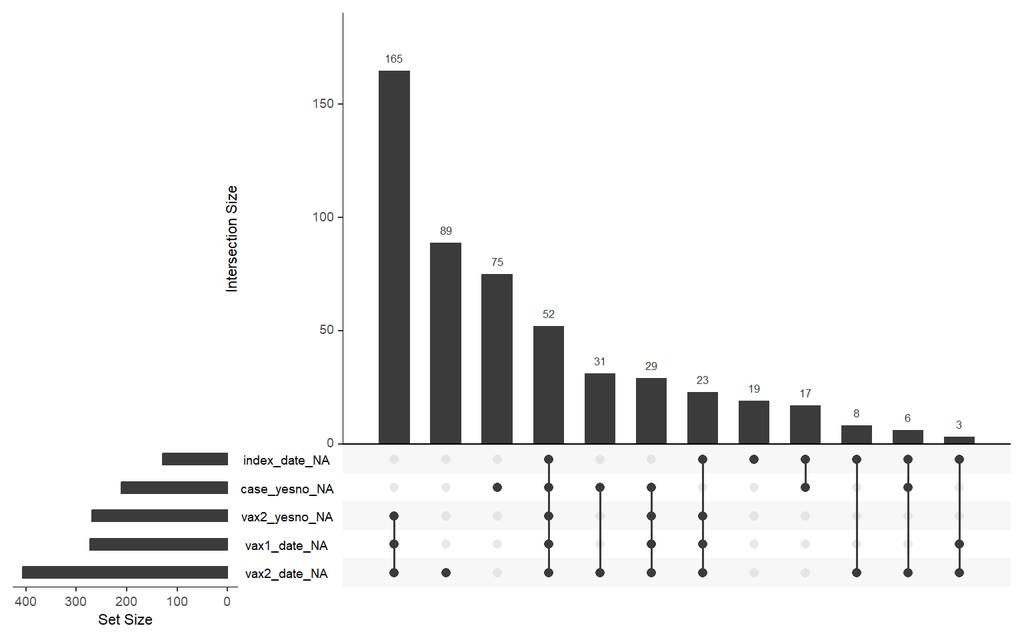

```r
mpoxve %>%
  select(case_yesno, index_date, vax1_yesno, vax1_date, vax2_yesno, vax2_date)%>%
  gg_miss_upset()
```

### Distribution of case status

**Figure 2. Case definition**

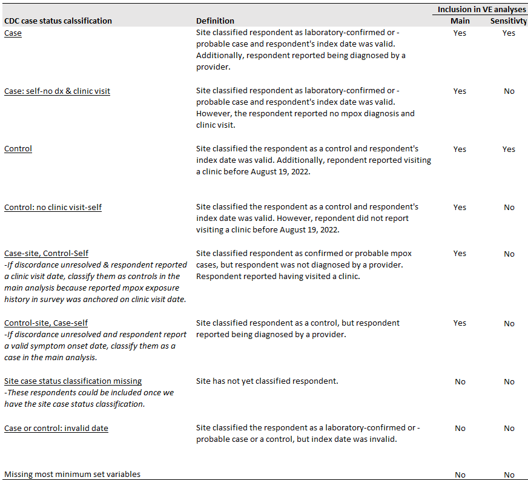

**Table 2. Case status**

```r
mpoxve %>%
  select(jid, caco_stat_cat,  caco, caco_sen) %>%
  tbl_summary(
    by = jid,
    label = list(caco_stat_cat ~ "All categories",
                 caco ~ "Main VE analysis",
                 caco_sen ~ "Sensitivity VE analysis"),
    missing = "always",
    missing_text = "Missing"

  )  %>%
  add_n() %>%
  add_overall() %>%
  modify_header(label = "**Case status**") %>% # update the column header
  bold_labels()
```

| **Case status** | **N** | **Overall**, N = 860<sup>1</sup> | **CA**, N = 12 | **LAC**, N = 151 | **CO**, N = 12 | **CT**, N = 13 | **GA**, N = 117 | **MD**, N = 50 | **MN**, N = 175 | **NYS**, N = 13 | **NYC**, N = 152 | **OR**, N = 111 | **TN**, N = 54 |
| --- | --- | --- | --- | --- | --- | --- | --- | --- | --- | --- | --- | --- | --- |
| All categories, n (%) | 858 |  |  |  |  |  |  |  |  |  |  |  |  |
| Case |  | 189 (22) | 0 (0) | 60 (40) | 8 (67) | 5 (38) | 36 (31) | 13 (27) | 29 (17) | 11 (85) | 0 (0) | 17 (15) | 10 (19) |
| Case: invalid date |  | 19 (2.2) | 0 (0) | 2 (1.3) | 0 (0) | 0 (0) | 0 (0) | 13 (27) | 0 (0) | 0 (0) | 0 (0) | 2 (1.8) | 2 (3.7) |
| Case: self-no dx & clinic visit |  | 3 (0.3) | 0 (0) | 2 (1.3) | 0 (0) | 1 (7.7) | 0 (0) | 0 (0) | 0 (0) | 0 (0) | 0 (0) | 0 (0) | 0 (0) |
| Control |  | 334 (39) | 0 (0) | 73 (48) | 3 (25) | 4 (31) | 44 (38) | 7 (14) | 106 (61) | 0 (0) | 0 (0) | 87 (78) | 10 (19) |
| Control: no clinic visit-self |  | 60 (7.0) | 0 (0) | 12 (7.9) | 0 (0) | 0 (0) | 12 (10) | 0 (0) | 33 (19) | 0 (0) | 0 (0) | 2 (1.8) | 1 (1.9) |
| Control: invalid date |  | 22 (2.6) | 0 (0) | 0 (0) | 0 (0) | 1 (7.7) | 4 (3.4) | 9 (18) | 4 (2.3) | 0 (0) | 0 (0) | 0 (0) | 4 (7.4) |
| Case-site, Control-self |  | 5 (0.6) | 0 (0) | 1 (0.7) | 0 (0) | 0 (0) | 2 (1.7) | 1 (2.0) | 1 (0.6) | 0 (0) | 0 (0) | 0 (0) | 0 (0) |
| Control-site, Case-self |  | 16 (1.9) | 0 (0) | 1 (0.7) | 0 (0) | 2 (15) | 5 (4.3) | 6 (12) | 0 (0) | 0 (0) | 0 (0) | 2 (1.8) | 0 (0) |
| Site-report missing |  | 210 (24) | 12 (100) | 0 (0) | 1 (8.3) | 0 (0) | 14 (12) | 0 (0) | 1 (0.6) | 2 (15) | 152 (100) | 1 (0.9) | 27 (50) |
| Missing |  | 2 | 0 | 0 | 0 | 0 | 0 | 1 | 1 | 0 | 0 | 0 | 0 |
| Main VE analysis, n (%) | 607 |  |  |  |  |  |  |  |  |  |  |  |  |
| Case |  | 208 (34) | 0 (NA) | 63 (42) | 8 (73) | 8 (67) | 41 (41) | 19 (70) | 29 (17) | 11 (100) | 0 (NA) | 19 (18) | 10 (48) |
| Control |  | 399 (66) | 0 (NA) | 86 (58) | 3 (27) | 4 (33) | 58 (59) | 8 (30) | 140 (83) | 0 (0) | 0 (NA) | 89 (82) | 11 (52) |
| Missing |  | 253 | 12 | 2 | 1 | 1 | 18 | 23 | 6 | 2 | 152 | 3 | 33 |
| Sensitivity VE analysis, n (%) | 523 |  |  |  |  |  |  |  |  |  |  |  |  |
| Case |  | 189 (36) | 0 (NA) | 60 (45) | 8 (73) | 5 (56) | 36 (45) | 13 (65) | 29 (21) | 11 (100) | 0 (NA) | 17 (16) | 10 (50) |
| Control |  | 334 (64) | 0 (NA) | 73 (55) | 3 (27) | 4 (44) | 44 (55) | 7 (35) | 106 (79) | 0 (0) | 0 (NA) | 87 (84) | 10 (50) |
| Missing |  | 337 | 12 | 18 | 1 | 4 | 37 | 30 | 40 | 2 | 152 | 7 | 34 |

<sup>1</sup> n (%)

### Distribution of site-reported clinic visit versus vaccine dose dates

**Table 3. Respondent with same clinic dates versus vaccination dates**

```r
mpoxve %>%
  mutate(clinic_vax_date = fct_relevel(as_factor(case_when(control_visit_date == dose1_date ~ "Clinic = D1",
                                                           control_visit_date == dose2_date ~ "Clinic = D2",
                                                           TRUE ~ as.character(NA))),
                                       "Clinic = D1", "Clinic = D2")) %>%
  filter(!is.na(clinic_vax_date)) %>%
  select(jid, clinic_vax_date) %>%
  tbl_summary(
    by = jid,
    label = list(clinic_vax_date ~ "Dates"),
    missing = "no"
  )  %>%
  add_n() %>%
  add_overall() %>%
  bold_labels()
```

| **Characteristic** | **N** | **Overall**, N = 102<sup>1</sup> | **CA**, N = 0 | **LAC**, N = 0 | **CO**, N = 1 | **CT**, N = 1 | **GA**, N = 16 | **MD**, N = 0 | **MN**, N = 54 | **NYS**, N = 0 | **NYC**, N = 0 | **OR**, N = 25 | **TN**, N = 5 |
| --- | --- | --- | --- | --- | --- | --- | --- | --- | --- | --- | --- | --- | --- |
| Dates, n (%) | 102 |  |  |  |  |  |  |  |  |  |  |  |  |
| Clinic = D1 |  | 53 (52) | 0 (NA) | 0 (NA) | 1 (100) | 1 (100) | 9 (56) | 0 (NA) | 22 (41) | 0 (NA) | 0 (NA) | 16 (64) | 4 (80) |
| Clinic = D2 |  | 49 (48) | 0 (NA) | 0 (NA) | 0 (0) | 0 (0) | 7 (44) | 0 (NA) | 32 (59) | 0 (NA) | 0 (NA) | 9 (36) | 1 (20) |

<sup>1</sup> n (%)

**Table 4. List of respondent with same clinic dates versus vaccination dates**

```r
clinic_vax <- mpoxve %>%
  mutate(clinic_vax_date = fct_relevel(as_factor(case_when(control_visit_date == dose1_date ~ "Clinic = D1",
                                                           control_visit_date == dose2_date ~ "Clinic = D2",
                                                           TRUE ~ as.character(NA))),
                                       "Clinic = D1", "Clinic = D2")) %>%
  filter(!is.na(clinic_vax_date)) %>%
  select(pid, caco_stat_cat, clinic_vax_date, case_yesno, vax_stat, index_date, clinic_date, control_visit_date, dose1_date, dose2_date) %>%
  arrange(clinic_vax_date)


#clipr::write_clip(clinic_vax)

clinic_vax %>%
     DT::datatable(., extensions='Buttons',
                     options = list(
                       searching = T,
                       pageLength = 10,
                       dom = 'Bfrtip',
                       buttons = c('csv')))
```

|  | pid | caco_stat_cat | clinic_vax_date | case_yesno | vax_stat | index_date | clinic_date | control_visit_date | dose1_date | dose2_date |
| --- | --- | --- | --- | --- | --- | --- | --- | --- | --- | --- |
| 1 | CO_14 | Control | Clinic = D1 | 3 | Unvaccinated | 2022-12-16 | 2022-12-16 | 2022-12-16 | 2022-12-16 | 2023-01-17 |
| 2 | CT_10 | Control | Clinic = D1 | 3 | Unvaccinated | 2022-08-25 | 2022-08-25 | 2022-08-25 | 2022-08-25 | 2022-09-23 |
| 3 | GA_15 | Control | Clinic = D1 | 3 | Unvaccinated | 2022-09-06 | 2022-09-06 | 2022-09-06 | 2022-09-06 |  |
| 4 | GA_25 | Control: no clinic visit-self | Clinic = D1 | 3 | Unvaccinated | 2022-08-22 |  | 2022-08-22 | 2022-08-22 |  |
| 5 | GA_40 | Control | Clinic = D1 | 3 | PEP | 2022-09-07 | 2022-09-07 | 2022-09-01 | 2022-09-01 | 2022-09-30 |
| 6 | GA_56 | Control | Clinic = D1 | 3 | Unvaccinated | 2022-10-04 | 2022-10-04 | 2022-10-04 | 2022-10-04 |  |
| 7 | GA_76 | Control | Clinic = D1 | 3 | Unvaccinated | 2022-08-24 | 2022-08-24 | 2022-08-26 | 2022-08-26 |  |
| 8 | GA_81 | Control | Clinic = D1 | 3 | Unvaccinated | 2022-08-30 | 2022-08-30 | 2022-08-30 | 2022-08-30 |  |
| 9 | GA_98 | Control | Clinic = D1 | 3 | Unvaccinated | 2022-09-22 | 2022-09-22 | 2022-09-29 | 2022-09-29 | 2022-10-28 |
| 10 | GA_127 | Control | Clinic = D1 | 3 | Partially vaccinated | 2022-10-13 | 2022-10-13 | 2022-08-19 | 2022-08-19 | 2022-10-13 |

[output cut: 92 more lines]

## **Part 2: Vaccination Status**

**Definitions:**

- Fully vaccinated: Receipt of two doses of JYNNEOS vaccine at least 24 days apart, with the second dose having been administered >13 days before index date (mpox symptom onset [for cases] or clinic visit date [for controls]).
- Partially vaccinated: Receipt of one dose of JYNNEOS vaccine >13 days before index date or respondents with receipt of two doses of JYNNEOS vaccine <14 days before index date.
- PEP vaccination: Receipt of one dose of JYNNEOS vaccine within 13 days after exposure to a person diagnosed with mpox (confirmed or probable case) and before index date.
- Unvaccinated: Without receipt of any doses of JYNNEOS vaccine or receipt of the vaccine after index date

**Figure 2. Dose #1 (D1), dose #2 (D2), and index event (IE) date scenarios**

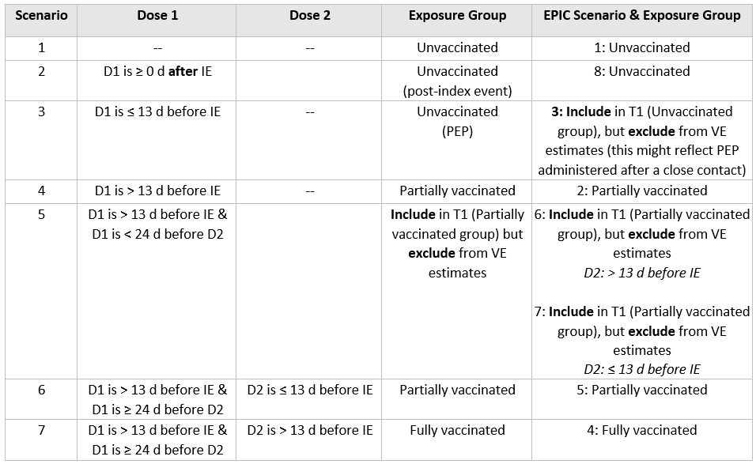

**Table 5. Distribution of vaccination status among those with a complete minimum data elements**

```r
mpoxve %>%
  filter(minset_vars == "Complete") %>%
  select(caco, vax_stat, vax_stat_ve) %>%
  tbl_summary(
    by = caco,
    label = list(vax_stat ~ "Descriptive table",
                 vax_stat_ve ~ "Main VE analysis*"

                 ),
     #percent = "column",
    missing = "always",
    missing_text = "Missing"

  )  %>%
  add_n() %>%
  add_overall() %>%
  bold_labels() %>%
  as_gt() %>%
  gt::tab_source_note(gt::md("*Missing = those exculded in scenario 5"))
```

| **Characteristic** | **N** | **Overall**, N = 595<sup>1</sup> | **Case**, N = 197 | **Control**, N = 398 |
| --- | --- | --- | --- | --- |
| Descriptive table, n (%) | 595 |  |  |  |
| Fully vaccinated |  | 131 (22) | 15 (7.6) | 116 (29) |
| Partially vaccinated |  | 158 (27) | 22 (11) | 136 (34) |
| PEP |  | 55 (9.2) | 23 (12) | 32 (8.0) |
| Unvaccinated |  | 251 (42) | 137 (70) | 114 (29) |
| Missing |  | 0 | 0 | 0 |
| Main VE analysis*, n (%) | 589 |  |  |  |
| Fully vaccinated |  | 131 (22) | 15 (7.6) | 116 (30) |
| Partially vaccinated |  | 152 (26) | 22 (11) | 130 (33) |
| PEP |  | 55 (9.3) | 23 (12) | 32 (8.2) |
| Unvaccinated |  | 251 (43) | 137 (70) | 114 (29) |
| Missing |  | 6 | 0 | 6 |

*Missing = those exculded in scenario 5  
<sup>1</sup> n (%)

## **Part 3: Vaccination related variables**

We restricted the tables below to those with complete set of minimum data elements.

### **Table 6. Dose 1 and Dose 2 vaccination interval: site & self**

```r
mpoxve %>%
  filter(minset_vars == "Complete") %>%
  select(caco, dose_int_cat_site, dose_int_cat_self) %>%
  tbl_summary(
    by = caco,
    label = list(dose_int_cat_site ~ "Site",
                 dose_int_cat_self ~ "Self"),
    missing = "always",
    missing_text = "Missing"

  )  %>%
  add_n() %>%
  add_overall() %>%
  bold_labels()
```

| **Characteristic** | **N** | **Overall**, N = 595<sup>1</sup> | **Case**, N = 197 | **Control**, N = 398 |
| --- | --- | --- | --- | --- |
| Site, n (%) | 590 |  |  |  |
| Dose #1 only |  | 92 (16) | 36 (18) | 56 (14) |
| <24 days |  | 2 (0.3) | 0 (0) | 2 (0.5) |
| 24-28 days |  | 89 (15) | 10 (5.1) | 79 (20) |
| >28 days |  | 219 (37) | 17 (8.7) | 202 (51) |
| Not Vaxed |  | 188 (32) | 133 (68) | 55 (14) |
| Missing |  | 5 | 1 | 4 |
| Self, n (%) | 595 |  |  |  |
| Dose #1 only |  | 93 (16) | 43 (22) | 50 (13) |
| <24 days |  | 38 (6.4) | 6 (3.0) | 32 (8.0) |
| 24-28 days |  | 62 (10) | 7 (3.6) | 55 (14) |
| >28 days |  | 237 (40) | 21 (11) | 216 (54) |
| Not Vaxed |  | 165 (28) | 120 (61) | 45 (11) |
| Missing |  | 0 | 0 | 0 |

<sup>1</sup> n (%)

### **Table 7. Vaccine dose number: site versus self**

```r
mpoxve %>%
  filter(minset_vars == "Complete") %>%
  select(caco, site_v_self_dose1, site_v_self_dose2) %>%
  tbl_summary(
    by = caco,
    label = list(site_v_self_dose1 ~ "Dose #1",
                 site_v_self_dose2 ~ "Dose #2"),
    missing = "always",
    missing_text = "Missing"

  )  %>%
  add_n() %>%
  add_overall() %>%
  bold_labels()
```

| **Characteristic** | **N** | **Overall**, N = 595<sup>1</sup> | **Case**, N = 197 | **Control**, N = 398 |
| --- | --- | --- | --- | --- |
| Dose #1, n (%) | 591 |  |  |  |
| Same |  | 565 (96) | 181 (92) | 384 (97) |
| Site-Vax |  | 1 (0.2) | 1 (0.5) | 0 (0) |
| Self-Vaxed |  | 25 (4.2) | 14 (7.1) | 11 (2.8) |
| Missing |  | 4 | 1 | 3 |
| Dose #2, n (%) | 405 |  |  |  |
| Same |  | 369 (91) | 55 (89) | 314 (92) |
| Site-Vax |  | 5 (1.2) | 0 (0) | 5 (1.5) |
| Self-Vaxed |  | 31 (7.7) | 7 (11) | 24 (7.0) |
| Missing |  | 190 | 135 | 55 |

<sup>1</sup> n (%)

### **Table 8. Vaccine administration date: site versus self (+/- 2 days)**

```r
mpoxve %>%
  filter(minset_vars == "Complete") %>%
  select(caco, site_v_self_vaxdate1, site_v_self_vaxdate2) %>%
  tbl_summary(
    by = caco,
    label = list(site_v_self_vaxdate1 ~ "Dose #1",
                 site_v_self_vaxdate2 ~ "Dose #2"),
    missing = "always",
    missing_text = "Missing"

  )  %>%
  add_n() %>%
  add_overall() %>%
  bold_labels()
```

| **Characteristic** | **N** | **Overall**, N = 595<sup>1</sup> | **Case**, N = 197 | **Control**, N = 398 |
| --- | --- | --- | --- | --- |
| Dose #1, n (%) | 401 |  |  |  |
| Abs > 2: Yes |  | 201 (50) | 35 (56) | 166 (49) |
| Abs > 2: No |  | 200 (50) | 27 (44) | 173 (51) |
| Missing |  | 194 | 135 | 59 |
| Dose #2, n (%) | 305 |  |  |  |
| Abs > 2: Yes |  | 133 (44) | 13 (48) | 120 (43) |
| Abs > 2: No |  | 172 (56) | 14 (52) | 158 (57) |
| Missing |  | 290 | 170 | 120 |

<sup>1</sup> n (%)

### **Table 9. Reasons for getting vaccinated by vaccination status categories**

```r
mpoxve %>%
  filter(minset_vars == "Complete") %>%
  select(vax_stat, why_vax___1, why_vax___2, why_vax___3, ) %>%
  tbl_summary(
    by = vax_stat,
    label = list(why_vax___1 ~ "Exposed and dose w/in 13d",
                 why_vax___2 ~ "High risk of mpox",
                 why_vax___3 ~ "Work exposure"),
    missing = "always",
    missing_text = "Missing"

  )  %>%
  add_n() %>%
  add_overall() %>%
  bold_labels()
```

| **Characteristic** | **N** | **Overall**, N = 597<sup>1</sup> | **Fully vaccinated**, N = 131 | **Partially vaccinated**, N = 159 | **PEP**, N = 55 | **Unvaccinated**, N = 252 |
| --- | --- | --- | --- | --- | --- | --- |
| Exposed and dose w/in 13d, n (%) | 597 | 49 (8.2) | 9 (6.9) | 12 (7.5) | 15 (27) | 13 (5.2) |
| Missing |  | 0 | 0 | 0 | 0 | 0 |
| High risk of mpox, n (%) | 597 | 349 (58) | 116 (89) | 131 (82) | 37 (67) | 65 (26) |
| Missing |  | 0 | 0 | 0 | 0 | 0 |
| Work exposure, n (%) | 597 | 20 (3.4) | 2 (1.5) | 10 (6.3) | 6 (11) | 2 (0.8) |
| Missing |  | 0 | 0 | 0 | 0 | 0 |

<sup>1</sup> n (%)

### **Table 10. VE model adjustment variables**

```r
mpoxve %>%
  filter(minset_vars == "Complete") %>%
  select(caco, age_cat, index_yrmo, sex_part_num_cat) %>%
  tbl_summary(
    by = caco,
    # label = list(why_vax___1 ~ "Exposed and dose w/in 13d",
    #              why_vax___2 ~ "High risk of mpox",
    #              why_vax___3 ~ "Work exposure"),
    missing = "always",
    missing_text = "Missing"

  )  %>%
  add_n() %>%
  add_overall() %>%
  bold_labels()
```

| **Characteristic** | **N** | **Overall**, N = 595<sup>1</sup> | **Case**, N = 197 | **Control**, N = 398 |
| --- | --- | --- | --- | --- |
| age_cat, n (%) | 594 |  |  |  |
| 18-29 |  | 155 (26) | 45 (23) | 110 (28) |
| 30-39 |  | 291 (49) | 96 (49) | 195 (49) |
| 40-49 |  | 143 (24) | 50 (26) | 93 (23) |
| 50 |  | 3 (0.5) | 3 (1.5) | 0 (0) |
| ≥51 |  | 2 (0.3) | 2 (1.0) | 0 (0) |
| Missing |  | 1 | 1 | 0 |
| index_yrmo, n (%) | 595 |  |  |  |
| 2022-08 |  | 155 (26) | 69 (35) | 86 (22) |
| 2022-09 |  | 215 (36) | 90 (46) | 125 (31) |
| 2022-10 |  | 115 (19) | 23 (12) | 92 (23) |
| 2022-11 |  | 62 (10) | 13 (6.6) | 49 (12) |
| 2022-12 |  | 42 (7.1) | 1 (0.5) | 41 (10) |
| 2023-01 |  | 6 (1.0) | 1 (0.5) | 5 (1.3) |
| Missing |  | 0 | 0 | 0 |
| sex_part_num_cat, n (%) | 514 |  |  |  |
| 0 |  | 20 (3.9) | 12 (6.4) | 8 (2.4) |
| 1-3 |  | 315 (61) | 115 (61) | 200 (61) |
| 4-6 |  | 115 (22) | 42 (22) | 73 (22) |
| 7-9 |  | 17 (3.3) | 3 (1.6) | 14 (4.3) |
| 10-12 |  | 22 (4.3) | 8 (4.3) | 14 (4.3) |
| 13+ |  | 25 (4.9) | 7 (3.7) | 18 (5.5) |
| Missing |  | 81 | 10 | 71 |

<sup>1</sup> n (%)